# Traveling Salesman Problem (TSP)

## Problem formulation

We have $N$ cities to visit. Each city must be visited exactly once, and we must return to the origin at the end of the trip. We want the shortest tour.

Notations:

- $x_{i, j} = 1$ if city $j$ follows city $i$ in the tour, and zero otherwise
- $D_{i, j}$ is the (euclidean) distance between cities $i$ and $j$

Mathematical formulation: \begin{align} \min_{x} \quad & \sum_{i, j} D_{i, j} x_{i, j}\\ \text{s.t.} \quad & x_{i, i} = 0, && \forall i \in \mathcal{N},\\ & \sum_{j \in \mathcal{N}} x_{i, j} = 1, && \forall i \in \mathcal{N},\\ & \sum_{i \in \mathcal{N}} x_{i, j} = 1, && \forall j \in \mathcal{N},\\ & \sum_{i \in \mathcal{S}, j \in \mathcal{S}} x_{i, j} \leq |\mathcal{S}| - 1, && \forall \mathcal{S} \subseteq \mathcal{N}, 2 \leq |\mathcal{S}| \leq N-1\\ & x_{i, j} \in \{0, 1\}, && \forall i, j \in \mathcal{N}^{2} \end{align}

Constraints $\sum_{i \in \mathcal{S}, j \in \mathcal{S}} x_{i, j} \leq |\mathcal{S}| - 1$ are *subtour elimination constraints*

⚠️ There are exponentially many subtours! ⚠️

## Problem setup

We provide:

- `TSPData` structure that contains distance matrix
- `generate_stp_data` to generate random data

```julia
data10 = generate_tsp_data(10)
plot(data10)
```

[figure not shown]

## Cut separation

Given a tentative tour

1. Identify individual sub-tours
2. Add subtour elimination constraint

```julia
example_tour = [8, 3, 4, 7, 6, 9, 2, 10, 5, 1]
plot_tour(data10, example_tour; title="Sub-tour example")
```

[figure not shown]

## Solving iteratively

1. Build the MIP without subtour constraints
2. Solve the MIP, get the current solution
3. Does the solution have subtours?
   1. No: done
   2. Yes: add subtour elimination constraints and go to 2.

Pros

- No callback to implement
- No restriction on what you can and cannot do

Cons

- Typically slower
- Only the last solution is feasible!

```julia
N = 35; data = generate_tsp_data(N)
plot(data)
```

[figure not shown]

```julia
tsp1, tours1 = solve_tsp_iterative(data);
```

```
Solving a TSP with 35 cities

Iter   #ST    Time
   1    16    0.01
   2    11    0.09
   3     7    0.26
   4     6    0.43
   5     4    0.70
   6     3    1.21
   7     4    1.63
   8     2    2.25
   9     3    3.15
  10     2    3.95
  11     1    4.73
TSP Solved at iteration 11
Final objective value: 4.8808
```

```julia
plot_tour(data, tours1[end][2], title="Iterative MIP: final solution")
```

[figure not shown]

## Using a lazy constraint callback

1. Build the MIP without subtour constraints
2. Create a callback to
   1. Find subtours (if any)
   2. Add subtour elimination constraints (lazy)
3. Register the callback
4. Call `optimize!`

Pros

- Typically faster
- Some heuristic solutions along the way

Cons

- You need to implement a callback

```julia
N = 35; data = generate_tsp_data(N)
plot(data)
```

[figure not shown]

```julia
tsp2, tours2 = solve_tsp_lazy(data);
```

```
Set parameter Username
Academic license - for non-commercial use only - expires 2022-10-30
Set parameter LazyConstraints to value 1
Solving a TSP with 35 cities

Gurobi Optimizer version 9.5.0 build v9.5.0rc5 (linux64)
Thread count: 4 physical cores, 8 logical processors, using up to 8 threads
Optimize a model with 105 rows, 1225 columns and 2485 nonzeros
Model fingerprint: 0x0ca4ecd8
Variable types: 0 continuous, 1225 integer (1225 binary)
Coefficient statistics:
  Matrix range     [1e+00, 1e+00]
  Objective range  [2e-02, 1e+00]
  Bounds range     [0e+00, 0e+00]
  RHS range        [1e+00, 1e+00]
Presolve removed 35 rows and 35 columns
Presolve time: 0.01s
Presolved: 70 rows, 1190 columns, 2380 nonzeros
Variable types: 0 continuous, 1190 integer (1190 binary)

Root relaxation: objective 4.138955e+00, 71 iterations, 0.00 seconds (0.00 work units)

    Nodes    |    Current Node    |     Objective Bounds      |     Work
 Expl Unexpl |  Obj  Depth IntInf | Incumbent    BestBd   Gap | It/Node Time

     0     0    4.13896    0   12          -    4.13896      -     -    0s
H    0     0                       5.9097138    4.13896  30.0%     -    0s
H    0     0                       5.7643798    4.13896  28.2%     -    0s
     0     0    4.26142    0   40    5.76438    4.26142  26.1%     -    0s
     0     2    4.37822    0   48    5.76438    4.37822  24.0%     -    0s
*  183   168              26       5.3334635    4.52660  15.1%   5.2    0s
*  185   168              29       5.2032913    4.52660  13.0%   5.2    0s
*  560   350              20       5.1703733    4.66744  9.73%   5.1    0s
*  618   381              30       5.1292440    4.68172  8.72%   5.1    0s
*  675   313              19       5.0138267    4.68767  6.51%   5.2    0s
*  676   294              19       4.9894012    4.68767  6.05%   5.2    0s
*  750   282              15       4.9391108    4.69714  4.90%   5.3    0s
*  920   315              15       4.9304920    4.72041  4.26%   5.4    0s
* 1518   392              15       4.9012796    4.75435  3.00%   5.5    0s
* 2537   435              21       4.8952856    4.80998  1.74%   5.5    0s
H 2575   381                       4.8807561    4.81359  1.38%   5.5    0s

Cutting planes:
  Cover: 10
  Lazy constraints: 350

Explored 3613 nodes (20102 simplex iterations) in 1.16 seconds (0.73 work units)
Thread count was 8 (of 8 available processors)

Solution count 10: 4.88076 4.89529 4.90128 ... 5.20329

Optimal solution found (tolerance 1.00e-04)
Best objective 4.880756109059e+00, best bound 4.880756109059e+00, gap 0.0000%

User-callback calls 7775, time in user-callback 0.09 sec
```

```julia
plot_tour(data, tours2[end][2], title="MIP + Lazy: final solution")
```

[figure not shown]

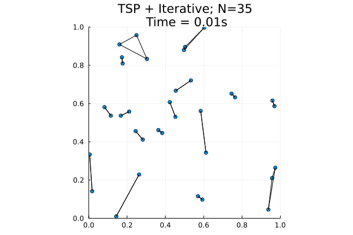

```julia
gif1
```

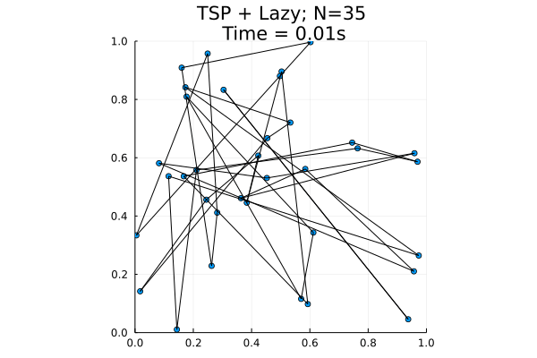

```julia
gif2
```